# MCS Coding to Solve Physics Problems 0

## Introduction to Python

#### Basics

Welcome to Python! This will be fun... maybe.

So, let's begin. Go to https://trinket.io/, create an account and start a python 3 programme!

If you are already familiar with python skip to the end for the key points of these notes and check you're happy with those.

Python is what is called a "scripting language". This means that you can do stuff in python without necessarily having to compile your code first. You *can* compile it, but you don't have to - you can directly use commands in the python shell and have them executed just by pressing "enter", no compiling required. We can do both by selecting the option *terminal* in the options by the play button on trinket.

So how does that work? We can print something like this:

```python
print("Hello!")
```

```
Hello!
```

You can also use python as a fancy version of a calculator. So, if you type in your python shell a simple mathematical command and press enter, python will calculate the answer for you:

```python
3 + 4
```

```
7
```

```python
100 - 22
```

```
78
```

```python
5 / 2
```

```
2.5
```

If we want to do some more complicated mathematical operation (as we often do in physics), we want to use a package called "numpy" in python, which is a very powerful and often-used library for numerical operations. This is how we tell python to use the numpy package:

```python
import numpy as np
```

We could also just write "import numpy", but then we would have to type every time we want to use a function from numpy "numpy.name_of_function", whereas with the "as np" we save ourselves a bit of typing and just have to write "np.name_of_function". This is how it works:

For example, the square root

```python
np.sqrt(2)
```

```
1.4142135623730951
```

Or, a number to the power of another numer (here, 2 to the power of 10):

```python
np.power(2, 10)
```

```
1024
```

### Arrays

Numpy makes it really easy to use arrays. Remember, arrays are a convenient way to bundle numbers together and have them ordered in a certain way so that we can find each entry in the array by its "house number" or index.

Let's say we want to create an array which contains the numbers 2, 4, 6, 8, 10. And we'll make our life easy by giving that array a name, say "arr", so that we can re-use that array at any time by typing "arr". Here's how that works:

```python
arr = np.array([2., 4., 6., 8., 10.])
```

If we want to print that array to remind ourselves what the numbers inside it were, we do this:

```python
print(arr)
```

```
[ 2.  4.  6.  8. 10.]
```

Like in C, the numbering of the elements starts with house number 0 (not 1). So if we want to print the first element from the array, we do this (take care to use square brackets for this, otherwise python doesn't understand you):

```python
print(arr[0])
```

```
2.0
```

Here's a neat trick. How do you print the last element in an array? Our array has 5 elements, but because we are counting from 0, the last element actually has the index number 4.

```python
print(arr[4])
```

```
10.0
```

But! Because python is awesome and your friend, you can also do this:

```python
print(arr[-1])
```

```
10.0
```

The index number "-1" will always give you the last element of an array, and you don't have to know how many elements there actually are in the array.

If we want several numbers form the array, say the first to third element, we do this with a colon (:) like so:

```python
print(arr[0:3])
```

```
[2. 4. 6.]
```

Here are a few other very usefull numpy commands, some of which you will need in your first python assignment.

This creates an array filled with zeros (and it will have as many zeros as the numbers you give in brackets):

```python
np.zeros(5)
```

```
array([0., 0., 0., 0., 0.])
```

If you want instead an array filled with ones:

```python
np.ones(3)
```

```
array([1., 1., 1.])
```

If you want an array filled with ascending numbers:

```python
np.arange(10)
```

```
array([0, 1, 2, 3, 4, 5, 6, 7, 8, 9])
```

The np.arange command will give you the numbers *up to, but not including to* the number that you specify in the brackets.

And if you want an array with ascending numbers from 3 to 11:

```python
np.arange(3, 12)
```

```
array([ 3,  4,  5,  6,  7,  8,  9, 10, 11])
```

If you want an array where the difference between the subsequent numbers is different than 1, you can do this:

```python
np.arange(2, 2.8, 0.1)
```

```
array([2. , 2.1, 2.2, 2.3, 2.4, 2.5, 2.6, 2.7])
```

```python
np.linspace(1, 100, 5)
```

```
array([  1.  ,  25.75,  50.5 ,  75.25, 100.  ])
```

To create an array with 5 *logarithmically* spaced numbers between the values 10^1 and 10^10:

```python
np.logspace(1, 10, 5)
```

```
array([1.00000000e+01, 1.77827941e+03, 3.16227766e+05, 5.62341325e+07,
       1.00000000e+10])
```

You can manipulate arrays very easily in python. For example, if you have an array with some numbers in it, and you want to multiply every number in the array by a factor of 2. Here's how that works in python:

First we create the array:

```python
arr = np.arange(2,12)

print(arr)
```

```
[ 2  3  4  5  6  7  8  9 10 11]
```

Then we make the new array with the multiplied values:

```python
newarr = 2 * arr

print(newarr)
```

```
[ 4  6  8 10 12 14 16 18 20 22]
```

Doddle

### Functions

Now we get to some real coding. We'll write a function that does something! Say we want to write a function that calculates the cubic root of a number. I.e. it calculates X to the power of 1/3. The Python way of writing "to the power of" is two stars: **. So in practice it looks like this:

```python
print(27**(1./3.))
```

```
3.0
```

Now to make that into a function is quite straightforward in Python. We don;t need any brackets or so to indicate where the beginning and end of the calculations inside the function is, we just use *indentation* (i.e. whitespace, specifically hitting the space bar 4 times).

This has the advantage that the code becomes easily readable for humans. So, remember, indent = 4 times space bar.

Here are the important bits about Python functions:

- They start with "def", then comes the name you have chosen for the function, and then in round brackets the name of the input variable, then a colon.
- The next lines, where you actually have the function calculate something, needs to start with 4 white spaces.
- You explicitly tell the function which value is the output value with "return" and then the name of the output.

Here's what that can look like:

```python
def cubicroot(x):
    result = x**(1./3.)
    return result
```

Now if we want to let the function calculate something, we "call" the function with some value for the input variable:

```python
print(cubicroot(1000))
```

```
9.999999999999998
```

As a side note, if you write a hashtag (#), then everything after the hashtag in that same line is not executed as a command, but it is just a comment.

As an example, we could also have written our cubic root function like this, and it would do exactly the same thing:

```python
# I'm being super verbose in this example with my function and variable names

def this_is_my_cubicroot_function(my_variable):
    exponent = 1./3. # I'm using an extra line to calculate the exponent I need in the next line
    my_calculated_output = my_variable**exponent # and here I insert the exponent
    a = 5 # here I do some extra stuff that I don't really need, but it doesn't make a difference
    b = 13.4
    return my_calculated_output # because I make the function only return the relevant output

print(this_is_my_cubicroot_function(12))
```

```
2.2894284851066637
```

Above we see again that there is no special "ending character" for a function. We just don't indent the line for the "print this_is_my_cubicroot_function(12)" commmand, and this tells Python that this is not part of the function any more.

### If-then-else

Let's use if-then-else to figure out if numbers are positive or negative. We can do that with the "if" statement. Python only does the thing mentioned after the "if" statement if the "if" statement is correct, otherwiese it doesn't do it.

```python
mynumber = 3

if mynumber >= 0: # Python checks if this is a true statement
    print("Number is positive.")
```

```
Number is positive.
```

Now, let's figure out how to calculate the absolute value of a number. This means we need the program to make a choice: if the input number is positive or 0, the absolute value is the same as the input, but if it is negative, the absolute value is the input multiplied by (-1).

This is how Python does if-then-else:

```python
mynumber = -5

if mynumber >= 0: # Python checks if this is a true statement
    print(mynumber) # if yes, Python executes this indented part
else: # else (if the statement above was not true)
    print (mynumber * (-1)) # Python executes this indented part.
```

```
5
```

Note that again 4 whitespaces are used to indicate what belongs inside the if or the else statement. And there is no explicit "then" necessary in Python!

Now let's make that a bit neater and put it into a function.

```python
def absolute(mynumber):
    if mynumber >= 0:
        outputnumber = mynumber
    else:
        outputnumber = mynumber * (-1)
    return outputnumber

print(absolute(-100))
```

```
100
```

Now here's an important thing with if-then-else: take care to cover all cases! So, let's say you want a function to calculate some stuff based on the input value, but you forget to mention all possible cases:

```python
def absolute(mynumber):
    if mynumber >= 0:
        outputnumber = mynumber
    if mynumber < -6: # So we haven't specified what Python should do if the number is between -6 and 0.
        outputnumber = mynumber * (-1)
    return outputnumber

print(absolute(-1))
```

```
---------------------------------------------------------------------------
UnboundLocalError                         Traceback (most recent call last)
<ipython-input-126-eaaa60d2561b> in <module>
      6     return outputnumber
      7
----> 8 print(absolute(-1))

<ipython-input-126-eaaa60d2561b> in absolute(mynumber)
      4     if mynumber < -6: # So we haven't specified what Python should do if the number is between -6 and 0.
      5         outputnumber = mynumber * (-1)
----> 6     return outputnumber
      7
      8 print(absolute(-1))

UnboundLocalError: local variable 'outputnumber' referenced before assignment
```

So we get an error. Always remember to cover all possible cases with if-then-else!

Now let's say we want to make it a bit more complicated, and we want our function to return 1 divided by the absolute value of the input number, *unless* the input number is zero. Then the result would be infinity, and we want the function to print a warning instead of trying to calculate the value.

This means we need to check 3 conditions, positive, negative, and equal to zero. We can use the "elif" statement for that, which is short for "else if":

```python
def divide_by_absolute(mynumber):
    if mynumber > 0:
        outputnumber = 1. / mynumber
    elif mynumber <0:
        outputnumber = -1 / mynumber
    else:
        print ('You are trying to divide by zero!')
        outputnumber = np.nan # This means 'Not a number' and is a placeholder for values like infinity.
    return outputnumber

print(divide_by_absolute(0))
```

```
You are trying to divide by zero!
nan
```

That's it!

### Loops

Loops are done with the "for" command in Python. We tell Python how often we want a thing done, and then what exactly we want done. Again, we use indentation to tell Python what is part is the loop and what isn't.

A simple example is this: We tell Python to calculate the sum of the natural numbers from 1 to 10:

```python
result = 0 # this is where we start (sum of zero numbers is zero)

for i in np.arange(1,11): # remember, np.arange(1,11) is the numbers [1,2,3,4,5,6,7,8,9,10]
    result = result + i

print(result)
```

```
55
```

This is such an easy example that we can actually check by hand if the result is correct:

```python
print(1+2+3+4+5+6+7+8+9+10)
```

```
55
```

Looks like we've done it right.

Now let's say we package that into a function, and the function gets two input variables: the number we want to start the addition with, and the last number we want to add. What would that look like?

```python
def number_adder(firstnumber, lastnumber):
    result = 0
    for i in np.arange(firstnumber, lastnumber + 1):
        result = result + i
    return result

print(number_adder(1, 10))
print(number_adder(2, 5))
```

```
55
14
```

Works!

### Plots

One of the strengths of python is that it is quite easy to have your data (say, your measurements) organized in arrays and then plot those in a nice viewgraph.

To do plotting in python, we use the library "matplotlib.pyplot", and again load the library with a convenient shortcut so that we have to do less typing further down the road:

```python
import matplotlib.pyplot as plt
```

Now let's define some data as the stuff that will go on the X axis of our plot, and some other data that will go on the Y axis.

Let's say our x values are integers between 0 and 10:

```python
x = np.arange(0, 10)
print(x)
```

```
[0 1 2 3 4 5 6 7 8 9]
```

And let's say our y values are the the x values to the power of two:

```python
y = x**2
print(y)
```

```
[ 0  1  4  9 16 25 36 49 64 81]
```

```python
plt.show()
```

Because the whole clicking around thing becomes a bit tedious, we can instead issue some extra commands to adjust the plot before we show it:

We can copy the following into the main.py tab and click run to create our programme

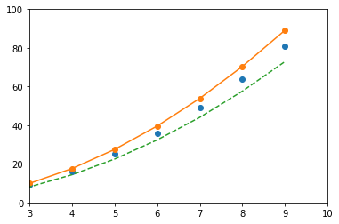

```python
import matplotlib.pyplot as plt
import numpy as np
x = np.arange(0, 10)
y = x**2
plt.plot(x, y, 'o') # this plots only circular markes, but no lines
plt.plot(x, 1.1*y, '-o') # this plots markers and lines
plt.plot(x, 0.9*y, '--') # this plots a dashed lines instead of a solid line
plt.axis([3, 10, 0, 100]) # this zooms into a certain part of the plot (x_start, x_end, y_start, y_end)
plt.show()
```

As you can see, matplotlib automatically chooses a new colour if you plot a new thing into the same plot. You can also directly control which colour you want to use with these abbreviations:

- 'b' = blue
- 'g' = green
- 'r' = red
- 'y' = yellow
- 'c' = cyan
- 'm' = magenta
- 'k' = black
- 'w' = white

And some different markers:

- 'o' for a big circle
- '.' for a small circle
- 's' for a square
- '*' for a star
- '+' for a plus sign
- and many more

And there are various line styles to use:

- '-' for a solid line
- '--' for a dashed line
- ':' for a dotted line
- '-.' for a dash-dotted line
- and just the marker symbol, but no symbol for the line to have only the markers.

Here is an example how to use that:

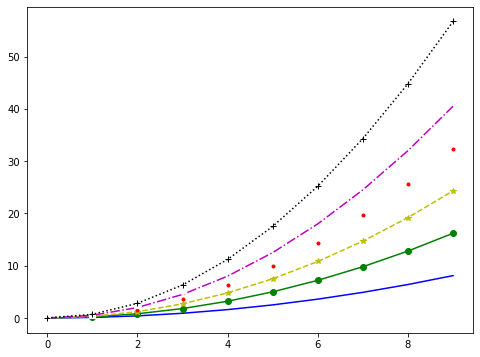

```python
plt.figure(figsize=(8,6))
plt.plot(x, 0.1*y, 'b-')
plt.plot(x, 0.2*y, 'g-o')
plt.plot(x, 0.3*y, 'y--*')
plt.plot(x, 0.4*y, 'r.')
plt.plot(x, 0.5*y, 'm-.')
plt.plot(x, 0.6*y, 'ws')
plt.plot(x, 0.7*y, 'k:+')
plt.show()
```

## Key Points from Session 1

3 concepts:

- arrays
- functions
- control flow:
  - loops ("for")
  - choices ("if-then-else")

### Arrays

What is an array? Basically, it is a list of things. Very often these things are numbers. So an example for an array is a list of all student numbers of students enrolled in a course. Say there are only 3 students enrolled, and they have the student numbers 5001, 6023, and 3098.

```python
stnumber = [5001, 6023, 3098]
```

We can now access the individual student numbers by their position in the array. For most programming languages (such as C and Python), these house numbers start with the number 0. So, the first student number is:

stnumber[0]

and the second one is

stnumber[1]

and so on.

So if we want to access the first student number, we write something like this in Python:

```python
print(stnumber[0])
```

```
5001
```

and the output will be "5001".

### Functions

What is a function? A function is a piece of code that takes some input, does something with the input, and then gives you an output. A function is like a little program inside the program, so to say. In analogy to mathematical equations, we can call the input we give the function "variables" (and the output would be the "result").

As an example, we can write a function that calculates something:

```python
def myfunction(x):
    y = x*3 + 0.1/x
    return y
```

This function takes a number x, calculates some number y from that according to the equation inside the function, and gives you back what it calculated for y.

So if we wanted the function to calculate the result for x=100, we would "call" the function like this:

```python
print(myfunction(100))
```

```
300.001
```

Or if we wanted the result for x=-3, we would call the function like this:

```python
print(myfunction(-3))
```

```
-9.033333333333333
```

### Control flow

Control flow is the order in which commands in a program are executed. If we don't do anything fancy, the program will just start executing the command in the first line, then go to the next line and so on until it reaches the end.

Two very common things we use in programming to make our life easier are Loops and Choices.

Let's start with **loops**.

```python
print(myfunction(1))

print(myfunction(2))

print(myfunction(3))
```

```
3.1
6.05
9.033333333333333
```

and so on.

We can instead use a loop and have the program go through the loop 20 times. This can be done like this in Python:

```python
for i in range(1, 21):
    print(myfunction(i))
```

```
3.1
6.05
9.033333333333333
12.025
15.02
18.016666666666666
21.014285714285716
24.0125
27.011111111111113
30.01
33.00909090909091
36.00833333333333
39.00769230769231
42.00714285714286
45.00666666666667
48.00625
51.00588235294118
54.00555555555555
57.00526315789474
60.005
```

"range(1, 21)" is a fancy Python way of saying "all numbers from 1 to 20". Don't worry about that too much for now, we'll get to that later. The loop will do the thing inside the loop ("print myfunction(i)") for all given values of i, which is 1 to 20. Much shorter than having to write 20 lines of code.

Now to the **choices**.

Sometimes we want a program to do one thing in one case, and a different thing in another case. Basically all programming languages use a structure of the form "if-then-else" for that, meaning "if this thing is true, then do that thing; else, do that other thing".

Here's an example. Say we have a number (let's say the program has asked the user to pick a number, so we don't know it beforehand). If that number is positive of 0, we want the program to give that same number as the output, without doing anything with it. If the number is negative, we want the program to give the positive version of the number as the output. Basically, this program will calculate the **absolute** of the input number.

Let's do that as a function:

```python
def absolute(x):
    if x>= 0:
        y = x
    else:
        y = -x
    return y
```

So if we now want our new function to calculate the absolute of the number 5, the result should obviously be 5:

```python
print(absolute(5))
```

```
5
```

And it is. And for "-10" as input we expect the output "10":

```python
print(absolute(-10))
```

```
10
```

## Exercises from Session 1

**Exercise 1:**

In a freshly opened python shell, what commands do you have to execute to

1a) create an array that contains all integer numbers from 0 up to 20, including the number 20?

1b) create an array that contains 13 values spread logarithmically between the values $10^2$ and $10^5$?

1c) create an array that contains the number 3 100 times in a row?

1d) create an array that contains the squares of the natural numbers from 1 to 10, i.e. contains the numbers 1, 4, 9, ..., 100?

1e) print the second number from the array you created in 1d)?

**Exercise 2:**

Make one matplotlib plot that shows two mathematical functions, one being $f(x) = 0.5x^2$ and the other one being $g(x) = 3x-4$. Plot this for x values from 0 to 15. Choose different marker symbols, line styles, and line widths for the two funtions.

**Exercise 3**:

Write a python function called "sillyfunction". This function shall take one number as input, and shall return the following output:

- if the input number is negative: "Booh!"
- if the input number is positive and a multiple of 7: "I wish I was a cat."
- if the input number is between 15 and 20 (including the borders): "This is how many cakes I ate for breakfast."
- if the input number is anything else: "o_o"

This means that if I type "sillyfunction(-4.3)", I should get the output "Booh!" in the python shell.

Hint: a built-in Python function to test if a number is a multiple of another number is the "modulo" function from the numpy package. It works like this: the result of np.mod(20, 5) is zero, because 20 is a multiple of 5. But the result of np.mod(22, 5) is 2, because dividing 22 by 5, using only integers, leaves the rest 2. This function can also be done with the % symbol.

**Exercise 4**:

Fibonacci numbers are a sequence of numbers that goes like this:

1, 1, 2, 3, 5, 8, 13, 21, 34, ...

As you can see, each number is the sum of the previous two numbers.

1a) Write a Python function called "fibonacci" that calculates the correct Fibonacci number from the above sequence, given the position in the sequence. So, "fibonacci(0)" should give the result "1", "fibonacci(5)" should give the result "8", and so on.

1b) Calculate the 50th Fibonacci number of that sequence.

**Exercise 5**:

Write a programme to test if a number $x$ is prime. You can input $x$ by using the input function. `x=int(input('Enter your value of x:'))` Once you've done that, think if your test could be made more efficient.